# Linear Regression

Yan Yan

April 28, 2015

The MASS library contains the Boston data set, which records medv (median house value) for 506 neighborhoods around Boston. We will seek to predict medv using 13 predictors sunch as rm (avarage number of rooms per house), age (average age of houses), and lstat (percent of households with low socioeconomic status).

```r
library(MASS)
names(Boston)
```

```
##  [1] "crim"    "zn"      "indus"   "chas"    "nox"     "rm"      "age"
##  [8] "dis"     "rad"     "tax"     "ptratio" "black"   "lstat"   "medv"
```

Use lm() function to fit a simple linear regression model.

```r
lm.fit = lm(medv ~ lstat, data = Boston)
```

or we can use

```r
attach(Boston) #attach Boston then R now recognizes the variables.
lm.fit = lm(medv ~ lstat)
```

so we can get the result via

```r
lm.fit
```

```
##
## Call:
## lm(formula = medv ~ lstat, data = Boston)
##
## Coefficients:
## (Intercept)        lstat
##       34.55        -0.95
```

```r
summary(lm.fit)
```

```
##
## Call:
## lm(formula = medv ~ lstat, data = Boston)
##
## Residuals:
##    Min     1Q Median     3Q    Max
## -15.17  -3.99  -1.32   2.03  24.50
##
## Coefficients:
##             Estimate Std. Error t value Pr(>|t|)
## (Intercept)  34.5538     0.5626    61.4   <2e-16 ***
## lstat        -0.9500     0.0387   -24.5   <2e-16 ***
## ---
## Signif. codes:  0 '***' 0.001 '**' 0.01 '*' 0.05 '.' 0.1 ' ' 1
##
## Residual standard error: 6.22 on 504 degrees of freedom
## Multiple R-squared:  0.544,  Adjusted R-squared:  0.543
## F-statistic:  602 on 1 and 504 DF,  p-value: <2e-16
```

We can use the names() function in order to find out what other pieces of information are stored in lm.fit, or we can use these quantities by name - e.g. lm.fit$coefficients, it is safer to use the extractor functions like coef() to access them.

```r
names(lm.fit)
```

```
##  [1] "coefficients"  "residuals"     "effects"       "rank"
##  [5] "fitted.values" "assign"        "qr"            "df.residual"
##  [9] "xlevels"       "call"          "terms"         "model"
```

```r
coef(lm.fit)
```

```
## (Intercept)       lstat
##       34.55       -0.95
```

In order to obtain a confidence interval for the coefficient estimates, we can use the confint() command.

```r
confint(lm.fit)
```

```
##              2.5 % 97.5 %
## (Intercept) 33.448 35.659
## lstat       -1.026 -0.874
```

The prediction() function can be used to produce confience intervals and prediction intervals for the prediction of medv for a given value of lstat

```r
predict(lm.fit, data.frame(lstat=(c(5,10,15))), interval = "confidence")
```

```
##     fit   lwr   upr
## 1 29.80 29.01 30.60
## 2 25.05 24.47 25.63
## 3 20.30 19.73 20.87
```

```r
predict(lm.fit, data.frame(lstat=(c(5,10,15))), interval = "prediction")
```

```
##     fit    lwr   upr
## 1 29.80 17.566 42.04
## 2 25.05 12.828 37.28
## 3 20.30  8.078 32.53
```

Plot medv and lstat along with the least squares regression line using the plot() and abline() functions.

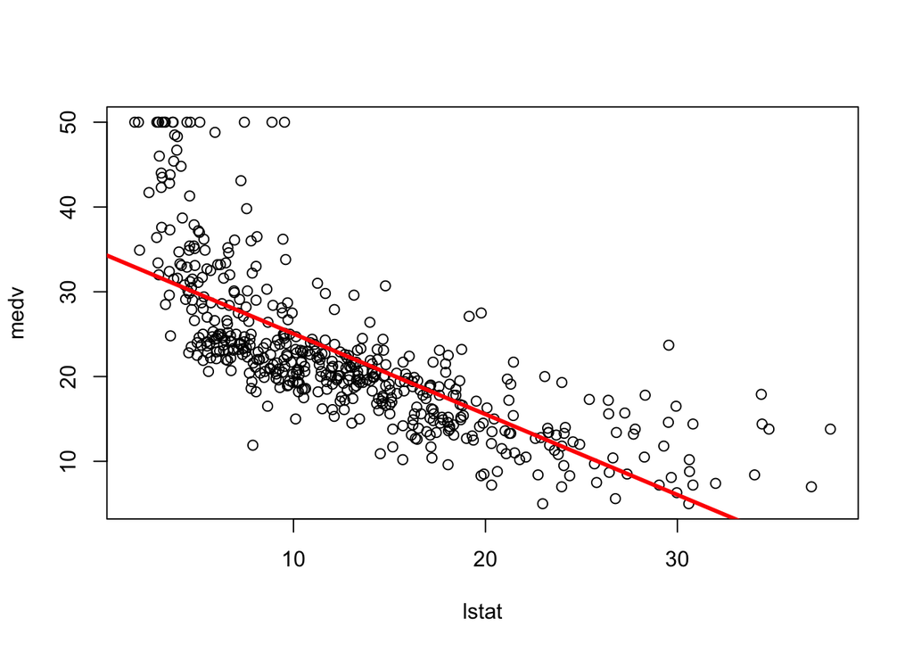

```r
attach(Boston)
plot(lstat, medv)
abline(lm.fit, lwd =3, col = "red")
```

Plot the residuals against the fitted values.

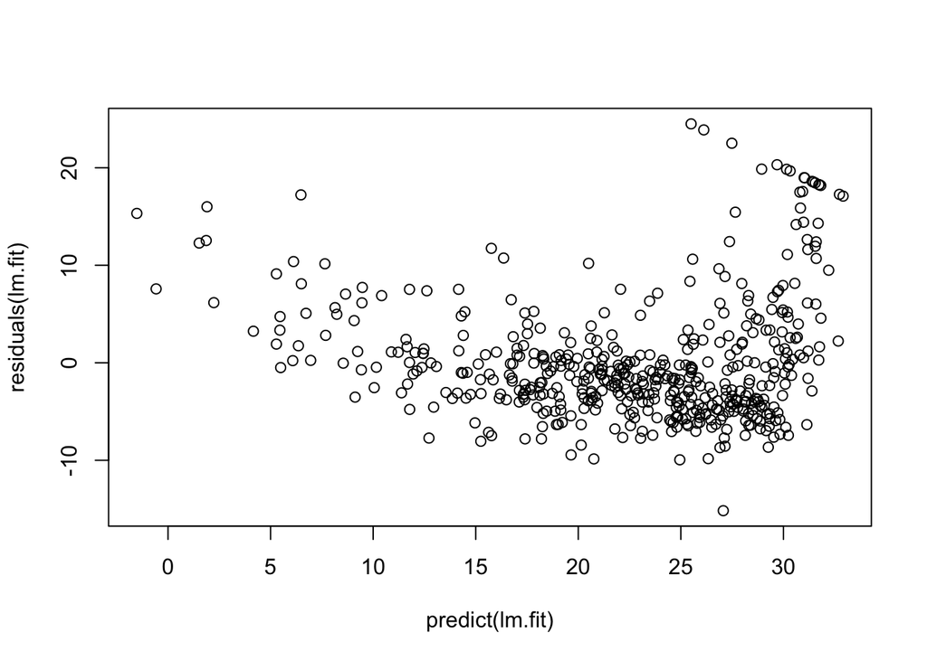

```r
plot(predict(lm.fit), residuals(lm.fit))
```

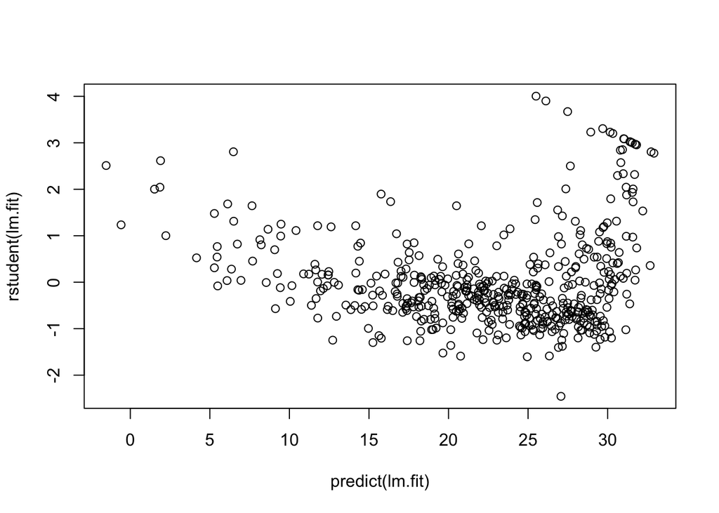

```r
plot(predict(lm.fit), rstudent(lm.fit))
```

On the basis of the residual plots, there is some evidence of non-linearity.

Leverage statistics can be computed for any number of predictors using the hatvalues() function.

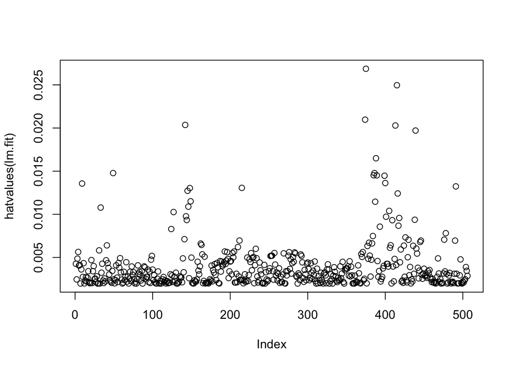

```r
plot(hatvalues(lm.fit))
```

```r
which.max(hatvalues(lm.fit)) #identify the index of the largest element of a vector.
```

```
## 375
## 375
```

# Multiple Linear Regression

To fit a multiple linear regression model using least squares, use lm() like:

```r
lm.fit = lm(medv ~ lstat + age, data = Boston)
summary(lm.fit)
```

```
##
## Call:
## lm(formula = medv ~ lstat + age, data = Boston)
##
## Residuals:
##    Min     1Q Median     3Q    Max
## -15.98  -3.98  -1.28   1.97  23.16
##
## Coefficients:
##             Estimate Std. Error t value Pr(>|t|)
## (Intercept)  33.2228     0.7308   45.46   <2e-16 ***
## lstat        -1.0321     0.0482  -21.42   <2e-16 ***
## age           0.0345     0.0122    2.83   0.0049 **
## ---
## Signif. codes:  0 '***' 0.001 '**' 0.01 '*' 0.05 '.' 0.1 ' ' 1
##
## Residual standard error: 6.17 on 503 degrees of freedom
## Multiple R-squared:  0.551,  Adjusted R-squared:  0.549
## F-statistic:  309 on 2 and 503 DF,  p-value: <2e-16
```

also we can use

```r
lm.fit = lm(medv ~., data = Boston)
summary(lm.fit)
```

```
##
## Call:
## lm(formula = medv ~ ., data = Boston)
##
## Residuals:
##     Min      1Q  Median      3Q     Max
## -15.594  -2.730  -0.518   1.777  26.199
##
## Coefficients:
##              Estimate Std. Error t value Pr(>|t|)
## (Intercept)  3.65e+01   5.10e+00    7.14  3.3e-12 ***
## crim        -1.08e-01   3.29e-02   -3.29  0.00109 **
## zn           4.64e-02   1.37e-02    3.38  0.00078 ***
## indus        2.06e-02   6.15e-02    0.33  0.73829
## chas         2.69e+00   8.62e-01    3.12  0.00193 **
## nox         -1.78e+01   3.82e+00   -4.65  4.2e-06 ***
## rm           3.81e+00   4.18e-01    9.12  < 2e-16 ***
## age          6.92e-04   1.32e-02    0.05  0.95823
## dis         -1.48e+00   1.99e-01   -7.40  6.0e-13 ***
## rad          3.06e-01   6.63e-02    4.61  5.1e-06 ***
## tax         -1.23e-02   3.76e-03   -3.28  0.00111 **
## ptratio     -9.53e-01   1.31e-01   -7.28  1.3e-12 ***
## black        9.31e-03   2.69e-03    3.47  0.00057 ***
## lstat       -5.25e-01   5.07e-02  -10.35  < 2e-16 ***
## ---
## Signif. codes:  0 '***' 0.001 '**' 0.01 '*' 0.05 '.' 0.1 ' ' 1
##
## Residual standard error: 4.75 on 492 degrees of freedom
## Multiple R-squared:  0.741,  Adjusted R-squared:  0.734
## F-statistic:  108 on 13 and 492 DF,  p-value: <2e-16
```

to consider all 13 variables as predictors.

The vif() function can be used to compute variance inflation factors.

```r
library(car)
vif(lm.fit)
```

```
##    crim      zn   indus    chas     nox      rm     age     dis     rad
##   1.792   2.299   3.992   1.074   4.394   1.934   3.101   3.956   7.484
##     tax ptratio   black   lstat
##   9.009   1.799   1.349   2.941
```

An expression to use all predictor but one is:

```r
lm.fit1 = lm(medv ~.-age, data = Boston)
summary(lm.fit1)
```

```
##
## Call:
## lm(formula = medv ~ . - age, data = Boston)
##
## Residuals:
##     Min      1Q  Median      3Q     Max
## -15.605  -2.731  -0.519   1.760  26.224
##
## Coefficients:
##              Estimate Std. Error t value Pr(>|t|)
## (Intercept)  36.43693    5.08012    7.17  2.7e-12 ***
## crim         -0.10801    0.03283   -3.29  0.00107 **
## zn            0.04633    0.01361    3.40  0.00072 ***
## indus         0.02056    0.06143    0.33  0.73799
## chas          2.68903    0.85960    3.13  0.00186 **
## nox         -17.71354    3.67931   -4.81  2.0e-06 ***
## rm            3.81439    0.40848    9.34  < 2e-16 ***
## dis          -1.47861    0.19061   -7.76  5.0e-14 ***
## rad           0.30579    0.06609    4.63  4.8e-06 ***
## tax          -0.01233    0.00376   -3.28  0.00110 **
## ptratio      -0.95221    0.13029   -7.31  1.1e-12 ***
## black         0.00932    0.00268    3.48  0.00054 ***
## lstat        -0.52385    0.04763  -11.00  < 2e-16 ***
## ---
## Signif. codes:  0 '***' 0.001 '**' 0.01 '*' 0.05 '.' 0.1 ' ' 1
##
## Residual standard error: 4.74 on 493 degrees of freedom
## Multiple R-squared:  0.741,  Adjusted R-squared:  0.734
## F-statistic:  117 on 12 and 493 DF,  p-value: <2e-16
```

And the update() function can be used

```r
lm.fit1 = update(lm.fit, ~.-age)
```

# Interaction Terms

The syntax lstat:black tells R to include an interaction term between lstat and black. The syntax lstatXage simultaneously includes lstat, age and interaction term lstatXage as predictors.

```r
summary(lm(medv ~ lstat*age, data = Boston))
```

```
##
## Call:
## lm(formula = medv ~ lstat * age, data = Boston)
##
## Residuals:
##    Min     1Q Median     3Q    Max
## -15.81  -4.04  -1.33   2.08  27.55
##
## Coefficients:
##              Estimate Std. Error t value Pr(>|t|)
## (Intercept) 36.088536   1.469835   24.55  < 2e-16 ***
## lstat       -1.392117   0.167456   -8.31  8.8e-16 ***
## age         -0.000721   0.019879   -0.04    0.971
## lstat:age    0.004156   0.001852    2.24    0.025 *
## ---
## Signif. codes:  0 '***' 0.001 '**' 0.01 '*' 0.05 '.' 0.1 ' ' 1
##
## Residual standard error: 6.15 on 502 degrees of freedom
## Multiple R-squared:  0.556,  Adjusted R-squared:  0.553
## F-statistic:  209 on 3 and 502 DF,  p-value: <2e-16
```

# Non-linear Transformations of the Predicros.

The square of X can be interpreted by using the function I(X^2):

```r
lm.fit2 = lm(medv ~ lstat + I(lstat^2))
summary(lm.fit2)
```

```
##
## Call:
## lm(formula = medv ~ lstat + I(lstat^2))
##
## Residuals:
##    Min     1Q Median     3Q    Max
## -15.28  -3.83  -0.53   2.31  25.41
##
## Coefficients:
##             Estimate Std. Error t value Pr(>|t|)
## (Intercept) 42.86201    0.87208    49.1   <2e-16 ***
## lstat       -2.33282    0.12380   -18.8   <2e-16 ***
## I(lstat^2)   0.04355    0.00375    11.6   <2e-16 ***
## ---
## Signif. codes:  0 '***' 0.001 '**' 0.01 '*' 0.05 '.' 0.1 ' ' 1
##
## Residual standard error: 5.52 on 503 degrees of freedom
## Multiple R-squared:  0.641,  Adjusted R-squared:  0.639
## F-statistic:  449 on 2 and 503 DF,  p-value: <2e-16
```

The near-zero p-value associated with the quadratic term suggests that it leads to an improved model. We use anova() function to further quantify the extent to which the quadratic fit is superior to the linear fit.

```r
lm.fit = lm(medv ~ lstat)
anova(lm.fit, lm.fit2)
```

```
## Analysis of Variance Table
##
## Model 1: medv ~ lstat
## Model 2: medv ~ lstat + I(lstat^2)
##   Res.Df   RSS Df Sum of Sq   F Pr(>F)
## 1    504 19472
## 2    503 15347  1      4125 135 <2e-16 ***
## ---
## Signif. codes:  0 '***' 0.001 '**' 0.01 '*' 0.05 '.' 0.1 ' ' 1
```

If we type

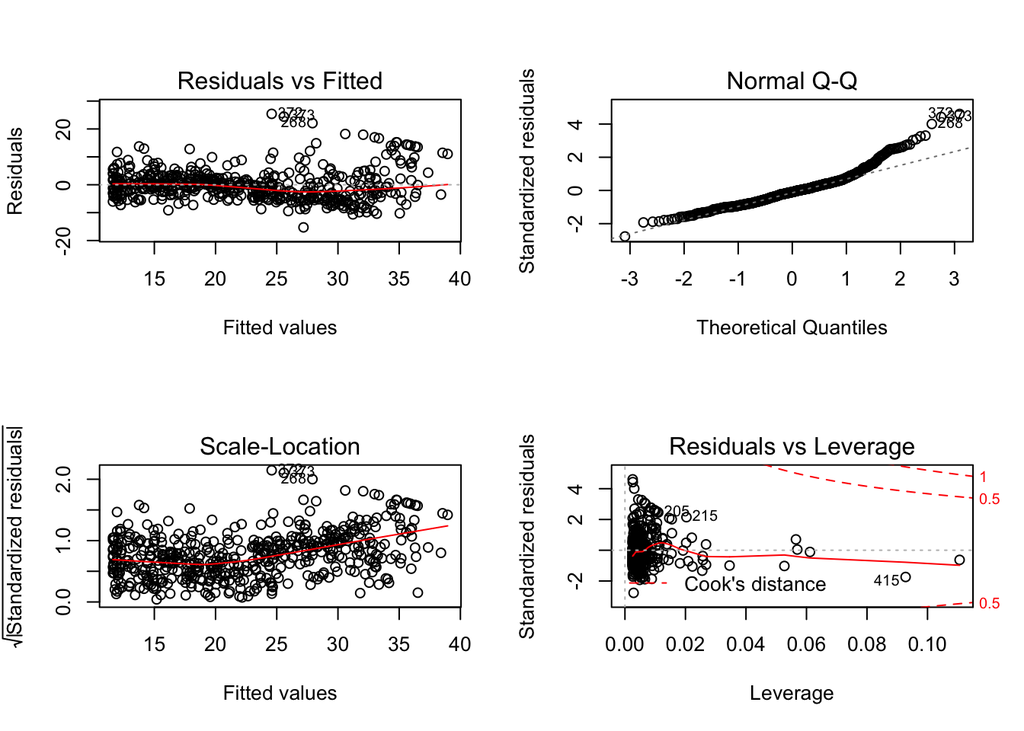

```r
par(mfrow=c(2,2))
plot(lm.fit2)
```

then we see that when the lstat^2 term is included in the model, there is little discernible pattern in the residuals.

Use the poly() function to create the polynomial within lm() like:

```r
lm.fit5=lm(medv ~ poly(lstat,5))
summary(lm.fit5)
```

```
##
## Call:
## lm(formula = medv ~ poly(lstat, 5))
##
## Residuals:
##     Min      1Q  Median      3Q     Max
## -13.543  -3.104  -0.705   2.084  27.115
##
## Coefficients:
##                 Estimate Std. Error t value Pr(>|t|)
## (Intercept)       22.533      0.232   97.20  < 2e-16 ***
## poly(lstat, 5)1 -152.460      5.215  -29.24  < 2e-16 ***
## poly(lstat, 5)2   64.227      5.215   12.32  < 2e-16 ***
## poly(lstat, 5)3  -27.051      5.215   -5.19  3.1e-07 ***
## poly(lstat, 5)4   25.452      5.215    4.88  1.4e-06 ***
## poly(lstat, 5)5  -19.252      5.215   -3.69  0.00025 ***
## ---
## Signif. codes:  0 '***' 0.001 '**' 0.01 '*' 0.05 '.' 0.1 ' ' 1
##
## Residual standard error: 5.21 on 500 degrees of freedom
## Multiple R-squared:  0.682,  Adjusted R-squared:  0.679
## F-statistic:  214 on 5 and 500 DF,  p-value: <2e-16
```

This suggests that including additional polynomial terms, up to fifth order, leads to an improvement in the model fit! A log transformation:

```r
summary(lm(medv~log(rm),data=Boston))
```

```
##
## Call:
## lm(formula = medv ~ log(rm), data = Boston)
##
## Residuals:
##    Min     1Q Median     3Q    Max
## -19.49  -2.87  -0.10   2.84  39.82
##
## Coefficients:
##             Estimate Std. Error t value Pr(>|t|)
## (Intercept)   -76.49       5.03   -15.2   <2e-16 ***
## log(rm)        54.05       2.74    19.7   <2e-16 ***
## ---
## Signif. codes:  0 '***' 0.001 '**' 0.01 '*' 0.05 '.' 0.1 ' ' 1
##
## Residual standard error: 6.91 on 504 degrees of freedom
## Multiple R-squared:  0.436,  Adjusted R-squared:  0.435
## F-statistic:  389 on 1 and 504 DF,  p-value: <2e-16
```

# Qualitative Predictors

Use the Carseats data

```r
library(ISLR)
data(Carseats)
names(Carseats)
```

```
##  [1] "Sales"       "CompPrice"   "Income"      "Advertising" "Population"
##  [6] "Price"       "ShelveLoc"   "Age"         "Education"   "Urban"
## [11] "US"
```

```r
lm.fit = lm(Sales~.+Income:Advertising + Price:Age, data=Carseats)
summary(lm.fit)
```

```
##
## Call:
## lm(formula = Sales ~ . + Income:Advertising + Price:Age, data = Carseats)
##
## Residuals:
##    Min     1Q Median     3Q    Max
## -2.921 -0.750  0.018  0.675  3.341
##
## Coefficients:
##                     Estimate Std. Error t value Pr(>|t|)
## (Intercept)         6.575565   1.008747    6.52  2.2e-10 ***
## CompPrice           0.092937   0.004118   22.57  < 2e-16 ***
## Income              0.010894   0.002604    4.18  3.6e-05 ***
## Advertising         0.070246   0.022609    3.11  0.00203 **
## Population          0.000159   0.000368    0.43  0.66533
## Price              -0.100806   0.007440  -13.55  < 2e-16 ***
## ShelveLocGood       4.848676   0.152838   31.72  < 2e-16 ***
## ShelveLocMedium     1.953262   0.125768   15.53  < 2e-16 ***
## Age                -0.057947   0.015951   -3.63  0.00032 ***
## Education          -0.020852   0.019613   -1.06  0.28836
## UrbanYes            0.140160   0.112402    1.25  0.21317
## USYes              -0.157557   0.148923   -1.06  0.29073
## Income:Advertising  0.000751   0.000278    2.70  0.00729 **
## Price:Age           0.000107   0.000133    0.80  0.42381
## ---
## Signif. codes:  0 '***' 0.001 '**' 0.01 '*' 0.05 '.' 0.1 ' ' 1
##
## Residual standard error: 1.01 on 386 degrees of freedom
## Multiple R-squared:  0.876,  Adjusted R-squared:  0.872
## F-statistic:  210 on 13 and 386 DF,  p-value: <2e-16
```

Use the contrasts() function returns the coding that R uses for the dummy variables.

```r
attach(Carseats)
contrasts(ShelveLoc)
```

```
##        Good Medium
## Bad       0      0
## Good      1      0
## Medium    0      1
```

R has created a ShelveLocGood dummy variable that takes on a value of 1 if the shelving location is good and 0 otherwise.

It has also created a ShelveLocMedium dummy variable that equals 1 if the shelving location is medium and 0 otherwise.

A bad shelving location corresponds to a zero for each of the two dummy variables.

The fact that the coefficient for Shelvelocgood in the regression output is positive indicates that a good shelving location is associated with high sales.

And ShelveLocMedum has a smaller positive coefficient, indicatingthat a medium shelving location leads to higher sales than a bad shelving location but lower sales thatn a good shelving location.